# **EDA RED WINE QUALITY**

## 1. Định nghĩa vấn đề (Define Problem)

📜 `Wine Dataset`

| Chỉ số | Ý nghĩa ngắn gọn |
| --- | --- |
| **Fixed acidity** | Axit không bay hơi (malic, lactic, tartaric…), đặc trưng cơ bản của rượu. |
| **Volatile acidity** | Axit bay hơi (chủ yếu acetic). Quá cao gây mùi giấm. |
| **Citric acid** | Axit hữu cơ nhẹ, tạo độ “tươi” cho rượu. |
| **Residual sugar** | Đường còn lại sau lên men (g/L), quyết định độ ngọt. |
| **Chlorides** | Hàm lượng muối (ion Cl⁻) trong rượu. |
| **Free sulfur dioxide** | SO₂ tự do, có tác dụng kháng khuẩn & chống oxi hóa. |
| **Total sulfur dioxide** | Tổng SO₂ (tự do + liên kết). |
| **Density** | Mật độ rượu so với nước, phụ thuộc cồn & đường. |
| **pH** | Độ axit/kiềm (0–14), rượu thường 3–4. |
| **Sulphates** | Phụ gia góp phần vào mức SO₂, bảo quản rượu. |
| **Alcohol** | % cồn của rượu. |
| **Quality** | Điểm đánh giá chất lượng cảm quan (3–8). |

## 2. Chuẩn bị vấn đề (Prepare Problem)

### 2.1. Khai báo thư viện (Load Libraries)

```python
import pandas as pd  #for data manipulation operations
import seaborn as sns  #for data visualization operations
import matplotlib.pyplot as plt  #for data visualization operations
```

### 2.2. Nạp dữ liệu (Load Dataset)

```python
wine = pd.read_csv("winequality-red.csv")
df = wine.copy()
df.head(n = 10)
```

|  | fixed acidity | volatile acidity | citric acid | residual sugar | chlorides | free sulfur dioxide | total sulfur dioxide | density | pH | sulphates | alcohol | quality |
| --- | --- | --- | --- | --- | --- | --- | --- | --- | --- | --- | --- | --- |
| 0 | 7.4 | 0.70 | 0.00 | 1.9 | 0.076 | 11.0 | 34.0 | 0.9978 | 3.51 | 0.56 | 9.4 | 5 |
| 1 | 7.8 | 0.88 | 0.00 | 2.6 | 0.098 | 25.0 | 67.0 | 0.9968 | 3.20 | 0.68 | 9.8 | 5 |
| 2 | 7.8 | 0.76 | 0.04 | 2.3 | 0.092 | 15.0 | 54.0 | 0.9970 | 3.26 | 0.65 | 9.8 | 5 |
| 3 | 11.2 | 0.28 | 0.56 | 1.9 | 0.075 | 17.0 | 60.0 | 0.9980 | 3.16 | 0.58 | 9.8 | 6 |
| 4 | 7.4 | 0.70 | 0.00 | 1.9 | 0.076 | 11.0 | 34.0 | 0.9978 | 3.51 | 0.56 | 9.4 | 5 |
| 5 | 7.4 | 0.66 | 0.00 | 1.8 | 0.075 | 13.0 | 40.0 | 0.9978 | 3.51 | 0.56 | 9.4 | 5 |
| 6 | 7.9 | 0.60 | 0.06 | 1.6 | 0.069 | 15.0 | 59.0 | 0.9964 | 3.30 | 0.46 | 9.4 | 5 |
| 7 | 7.3 | 0.65 | 0.00 | 1.2 | 0.065 | 15.0 | 21.0 | 0.9946 | 3.39 | 0.47 | 10.0 | 7 |
| 8 | 7.8 | 0.58 | 0.02 | 2.0 | 0.073 | 9.0 | 18.0 | 0.9968 | 3.36 | 0.57 | 9.5 | 7 |
| 9 | 7.5 | 0.50 | 0.36 | 6.1 | 0.071 | 17.0 | 102.0 | 0.9978 | 3.35 | 0.80 | 10.5 | 5 |

### 2.3. Thông tin cơ bản

```python
df.info()
```

```
<class 'pandas.core.frame.DataFrame'>
RangeIndex: 1599 entries, 0 to 1598
Data columns (total 12 columns):
 #   Column                Non-Null Count  Dtype
---  ------                --------------  -----
 0   fixed acidity         1599 non-null   float64
 1   volatile acidity      1599 non-null   float64
 2   citric acid           1599 non-null   float64
 3   residual sugar        1599 non-null   float64
 4   chlorides             1599 non-null   float64
 5   free sulfur dioxide   1599 non-null   float64
 6   total sulfur dioxide  1599 non-null   float64
 7   density               1599 non-null   float64
 8   pH                    1599 non-null   float64
 9   sulphates             1599 non-null   float64
 10  alcohol               1599 non-null   float64
 11  quality               1599 non-null   int64
dtypes: float64(11), int64(1)
memory usage: 150.0 KB
```

**Dataset size:** 1599 dòng, 12 cột  
**Data types:** Tất cả biến đều dạng số (numeric)  
**Missing values:** Không có giá trị null

## 3. Làm sạch, xem xét

### 3.1. Thống kê mô tả (Descriptive Statistics)

#### (1) **Hiển thị một số thông tin về dữ liệu**

```python
# shape
print(f'+ Shape: {df.shape}')

# types
print(f'+ Data Types: \n{df.dtypes}')

# head, tail
print(f'+ Contents: ')
display(df.head(5))
display(df.tail(5))

# info
df.info()
```

```
+ Shape: (1599, 12)
+ Data Types:
fixed acidity           float64
volatile acidity        float64
citric acid             float64
residual sugar          float64
chlorides               float64
free sulfur dioxide     float64
total sulfur dioxide    float64
density                 float64
pH                      float64
sulphates               float64
alcohol                 float64
quality                   int64
dtype: object
+ Contents:
```

|  | fixed acidity | volatile acidity | citric acid | residual sugar | chlorides | free sulfur dioxide | total sulfur dioxide | density | pH | sulphates | alcohol | quality |
| --- | --- | --- | --- | --- | --- | --- | --- | --- | --- | --- | --- | --- |
| 0 | 7.4 | 0.70 | 0.00 | 1.9 | 0.076 | 11.0 | 34.0 | 0.9978 | 3.51 | 0.56 | 9.4 | 5 |
| 1 | 7.8 | 0.88 | 0.00 | 2.6 | 0.098 | 25.0 | 67.0 | 0.9968 | 3.20 | 0.68 | 9.8 | 5 |
| 2 | 7.8 | 0.76 | 0.04 | 2.3 | 0.092 | 15.0 | 54.0 | 0.9970 | 3.26 | 0.65 | 9.8 | 5 |
| 3 | 11.2 | 0.28 | 0.56 | 1.9 | 0.075 | 17.0 | 60.0 | 0.9980 | 3.16 | 0.58 | 9.8 | 6 |
| 4 | 7.4 | 0.70 | 0.00 | 1.9 | 0.076 | 11.0 | 34.0 | 0.9978 | 3.51 | 0.56 | 9.4 | 5 |

|  | fixed acidity | volatile acidity | citric acid | residual sugar | chlorides | free sulfur dioxide | total sulfur dioxide | density | pH | sulphates | alcohol | quality |
| --- | --- | --- | --- | --- | --- | --- | --- | --- | --- | --- | --- | --- |
| 1594 | 6.2 | 0.600 | 0.08 | 2.0 | 0.090 | 32.0 | 44.0 | 0.99490 | 3.45 | 0.58 | 10.5 | 5 |
| 1595 | 5.9 | 0.550 | 0.10 | 2.2 | 0.062 | 39.0 | 51.0 | 0.99512 | 3.52 | 0.76 | 11.2 | 6 |
| 1596 | 6.3 | 0.510 | 0.13 | 2.3 | 0.076 | 29.0 | 40.0 | 0.99574 | 3.42 | 0.75 | 11.0 | 6 |
| 1597 | 5.9 | 0.645 | 0.12 | 2.0 | 0.075 | 32.0 | 44.0 | 0.99547 | 3.57 | 0.71 | 10.2 | 5 |
| 1598 | 6.0 | 0.310 | 0.47 | 3.6 | 0.067 | 18.0 | 42.0 | 0.99549 | 3.39 | 0.66 | 11.0 | 6 |

```
<class 'pandas.core.frame.DataFrame'>
RangeIndex: 1599 entries, 0 to 1598
Data columns (total 12 columns):
 #   Column                Non-Null Count  Dtype
---  ------                --------------  -----
 0   fixed acidity         1599 non-null   float64
 1   volatile acidity      1599 non-null   float64
 2   citric acid           1599 non-null   float64
 3   residual sugar        1599 non-null   float64
 4   chlorides             1599 non-null   float64
 5   free sulfur dioxide   1599 non-null   float64
 6   total sulfur dioxide  1599 non-null   float64
 7   density               1599 non-null   float64
 8   pH                    1599 non-null   float64
 9   sulphates             1599 non-null   float64
 10  alcohol               1599 non-null   float64
 11  quality               1599 non-null   int64
dtypes: float64(11), int64(1)
memory usage: 150.0 KB
```

#### (2) **Kiểm tra tính toàn vẹn của dữ liệu**

```python
has_null = df.isnull().sum().any()
has_nan  = df.isna().sum().any()
n_duplicated = df.duplicated().sum()
print(f'Tính toàn vẹn dữ liệu:')
print(f'+ Có giá trị Null: {has_null}')
if has_null:
    display.display(df[df.isnull().any(axis=1)])
print(f'+ Có giá trị Nan: {has_nan}')
if has_nan:
    display.display(df[df.isna().any(axis=1)])
print(f'+ Số dòng trùng: {n_duplicated}')
```

```
Tính toàn vẹn dữ liệu:
+ Có giá trị Null: False
+ Có giá trị Nan: False
+ Số dòng trùng: 240
```

**Xử lý trùng lặp dữ liệu**

```python
df.drop_duplicates(keep='first', inplace=True)
```

```python
has_null = df.isnull().sum().any()
has_nan  = df.isna().sum().any()
n_duplicated = df.duplicated().sum()
print(f'Tính toàn vẹn dữ liệu:')
print(f'+ Có giá trị Null: {has_null}')
if has_null:
    display.display(df[df.isnull().any(axis=1)])
print(f'+ Có giá trị Nan: {has_nan}')
if has_nan:
    display.display(df[df.isna().any(axis=1)])
print(f'+ Số dòng trùng: {n_duplicated}')
```

```
Tính toàn vẹn dữ liệu:
+ Có giá trị Null: False
+ Có giá trị Nan: False
+ Số dòng trùng: 0
```

**Đổi tên cột để dễ truy vấn**

```python
df.rename(columns = {"fixed acidity": "fixed_acidity", "volatile acidity": "volatile_acidity",
                    "citric acid": "citric_acid", "residual sugar": "residual_sugar",
                    "chlorides": "chlorides", "free sulfur dioxide": "free_sulfur_dioxide",
                    "total sulfur dioxide": "total_sulfur_dioxide"}, inplace = True)
```

```python
display(df)
```

|  | fixed_acidity | volatile_acidity | citric_acid | residual_sugar | chlorides | free_sulfur_dioxide | total_sulfur_dioxide | density | pH | sulphates | alcohol | quality |
| --- | --- | --- | --- | --- | --- | --- | --- | --- | --- | --- | --- | --- |
| 0 | 7.4 | 0.700 | 0.00 | 1.90 | 0.076 | 11.0 | 34.0 | 0.99780 | 3.51 | 0.56 | 9.400000 | 5 |
| 1 | 7.8 | 0.880 | 0.00 | 2.60 | 0.098 | 25.0 | 67.0 | 0.99680 | 3.20 | 0.68 | 9.800000 | 5 |
| 2 | 7.8 | 0.760 | 0.04 | 2.30 | 0.092 | 15.0 | 54.0 | 0.99700 | 3.26 | 0.65 | 9.800000 | 5 |
| 3 | 11.2 | 0.280 | 0.56 | 1.90 | 0.075 | 17.0 | 60.0 | 0.99800 | 3.16 | 0.58 | 9.800000 | 6 |
| 5 | 7.4 | 0.660 | 0.00 | 1.80 | 0.075 | 13.0 | 40.0 | 0.99780 | 3.51 | 0.56 | 9.400000 | 5 |
| 6 | 7.9 | 0.600 | 0.06 | 1.60 | 0.069 | 15.0 | 59.0 | 0.99640 | 3.30 | 0.46 | 9.400000 | 5 |
| 7 | 7.3 | 0.650 | 0.00 | 1.20 | 0.065 | 15.0 | 21.0 | 0.99460 | 3.39 | 0.47 | 10.000000 | 7 |
| 8 | 7.8 | 0.580 | 0.02 | 2.00 | 0.073 | 9.0 | 18.0 | 0.99680 | 3.36 | 0.57 | 9.500000 | 7 |
| 9 | 7.5 | 0.500 | 0.36 | 6.10 | 0.071 | 17.0 | 102.0 | 0.99780 | 3.35 | 0.80 | 10.500000 | 5 |
| 10 | 6.7 | 0.580 | 0.08 | 1.80 | 0.097 | 15.0 | 65.0 | 0.99590 | 3.28 | 0.54 | 9.200000 | 5 |
| 12 | 5.6 | 0.615 | 0.00 | 1.60 | 0.089 | 16.0 | 59.0 | 0.99430 | 3.58 | 0.52 | 9.900000 | 5 |
| 13 | 7.8 | 0.610 | 0.29 | 1.60 | 0.114 | 9.0 | 29.0 | 0.99740 | 3.26 | 1.56 | 9.100000 | 5 |
| 14 | 8.9 | 0.620 | 0.18 | 3.80 | 0.176 | 52.0 | 145.0 | 0.99860 | 3.16 | 0.88 | 9.200000 | 5 |
| 15 | 8.9 | 0.620 | 0.19 | 3.90 | 0.170 | 51.0 | 148.0 | 0.99860 | 3.17 | 0.93 | 9.200000 | 5 |
| 16 | 8.5 | 0.280 | 0.56 | 1.80 | 0.092 | 35.0 | 103.0 | 0.99690 | 3.30 | 0.75 | 10.500000 | 7 |
| 17 | 8.1 | 0.560 | 0.28 | 1.70 | 0.368 | 16.0 | 56.0 | 0.99680 | 3.11 | 1.28 | 9.300000 | 5 |
| 18 | 7.4 | 0.590 | 0.08 | 4.40 | 0.086 | 6.0 | 29.0 | 0.99740 | 3.38 | 0.50 | 9.000000 | 4 |
| 19 | 7.9 | 0.320 | 0.51 | 1.80 | 0.341 | 17.0 | 56.0 | 0.99690 | 3.04 | 1.08 | 9.200000 | 6 |
| 20 | 8.9 | 0.220 | 0.48 | 1.80 | 0.077 | 29.0 | 60.0 | 0.99680 | 3.39 | 0.53 | 9.400000 | 6 |
| 21 | 7.6 | 0.390 | 0.31 | 2.30 | 0.082 | 23.0 | 71.0 | 0.99820 | 3.52 | 0.65 | 9.700000 | 5 |
| 22 | 7.9 | 0.430 | 0.21 | 1.60 | 0.106 | 10.0 | 37.0 | 0.99660 | 3.17 | 0.91 | 9.500000 | 5 |
| 23 | 8.5 | 0.490 | 0.11 | 2.30 | 0.084 | 9.0 | 67.0 | 0.99680 | 3.17 | 0.53 | 9.400000 | 5 |
| 24 | 6.9 | 0.400 | 0.14 | 2.40 | 0.085 | 21.0 | 40.0 | 0.99680 | 3.43 | 0.63 | 9.700000 | 6 |
| 25 | 6.3 | 0.390 | 0.16 | 1.40 | 0.080 | 11.0 | 23.0 | 0.99550 | 3.34 | 0.56 | 9.300000 | 5 |
| 26 | 7.6 | 0.410 | 0.24 | 1.80 | 0.080 | 4.0 | 11.0 | 0.99620 | 3.28 | 0.59 | 9.500000 | 5 |
| 28 | 7.1 | 0.710 | 0.00 | 1.90 | 0.080 | 14.0 | 35.0 | 0.99720 | 3.47 | 0.55 | 9.400000 | 5 |
| 29 | 7.8 | 0.645 | 0.00 | 2.00 | 0.082 | 8.0 | 16.0 | 0.99640 | 3.38 | 0.59 | 9.800000 | 6 |
| 30 | 6.7 | 0.675 | 0.07 | 2.40 | 0.089 | 17.0 | 82.0 | 0.99580 | 3.35 | 0.54 | 10.100000 | 5 |
| 31 | 6.9 | 0.685 | 0.00 | 2.50 | 0.105 | 22.0 | 37.0 | 0.99660 | 3.46 | 0.57 | 10.600000 | 6 |
| 32 | 8.3 | 0.655 | 0.12 | 2.30 | 0.083 | 15.0 | 113.0 | 0.99660 | 3.17 | 0.66 | 9.800000 | 5 |

[output cut: 1329 more lines]

#### (3) **Các tính chất thống kê trên dữ liệu số**

- Count, Mean, Standard Deviation, Minimum Value
- 25th Percentile, 50th Percentile (Median), 75th Percentile, Maximum Value

```python
description = df.describe().T
display(description)
```

|  | count | mean | std | min | 25% | 50% | 75% | max |
| --- | --- | --- | --- | --- | --- | --- | --- | --- |
| fixed_acidity | 1359.0 | 8.310596 | 1.736990 | 4.60000 | 7.1000 | 7.9000 | 9.20000 | 15.90000 |
| volatile_acidity | 1359.0 | 0.529478 | 0.183031 | 0.12000 | 0.3900 | 0.5200 | 0.64000 | 1.58000 |
| citric_acid | 1359.0 | 0.272333 | 0.195537 | 0.00000 | 0.0900 | 0.2600 | 0.43000 | 1.00000 |
| residual_sugar | 1359.0 | 2.523400 | 1.352314 | 0.90000 | 1.9000 | 2.2000 | 2.60000 | 15.50000 |
| chlorides | 1359.0 | 0.088124 | 0.049377 | 0.01200 | 0.0700 | 0.0790 | 0.09100 | 0.61100 |
| free_sulfur_dioxide | 1359.0 | 15.893304 | 10.447270 | 1.00000 | 7.0000 | 14.0000 | 21.00000 | 72.00000 |
| total_sulfur_dioxide | 1359.0 | 46.825975 | 33.408946 | 6.00000 | 22.0000 | 38.0000 | 63.00000 | 289.00000 |
| density | 1359.0 | 0.996709 | 0.001869 | 0.99007 | 0.9956 | 0.9967 | 0.99782 | 1.00369 |
| pH | 1359.0 | 3.309787 | 0.155036 | 2.74000 | 3.2100 | 3.3100 | 3.40000 | 4.01000 |
| sulphates | 1359.0 | 0.658705 | 0.170667 | 0.33000 | 0.5500 | 0.6200 | 0.73000 | 2.00000 |
| alcohol | 1359.0 | 10.432315 | 1.082065 | 8.40000 | 9.5000 | 10.2000 | 11.10000 | 14.90000 |
| quality | 1359.0 | 5.623252 | 0.823578 | 3.00000 | 5.0000 | 6.0000 | 6.00000 | 8.00000 |

## 4. Phân tích dữ liệu (Analyze Data)

### 4.1 Biểu đồ tần suất (displot)

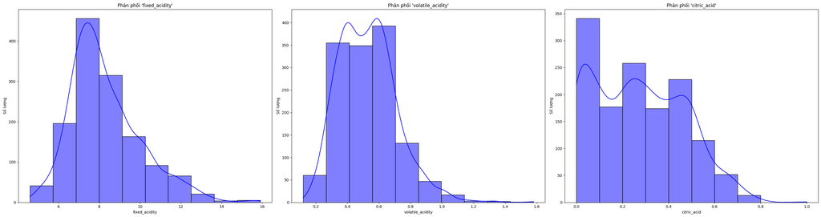

```python
fig, axes = plt.subplots(1, 3, figsize=(30, 8))

# fixed_acidity
sns.histplot(
    data=df, x="fixed_acidity",
    bins=10, kde=True, color="blue",
    ax=axes[0]
)
axes[0].set_title("Phân phối 'fixed_acidity'")
axes[0].set_xlabel("fixed_acidity")
axes[0].set_ylabel("Số lượng")

# volatile_acidity
sns.histplot(
    data=df, x="volatile_acidity",
    bins=10, kde=True, color="blue",
    ax=axes[1]
)
axes[1].set_title("Phân phối 'volatile_acidity'")
axes[1].set_xlabel("volatile_acidity")
axes[1].set_ylabel("Số lượng")

# citric_acid
sns.histplot(
    data=df, x="citric_acid",
    bins=10, kde=True, color="blue",
    ax=axes[2]
)
axes[2].set_title("Phân phối 'citric_acid'")
axes[2].set_xlabel("citric_acid")
axes[2].set_ylabel("Số lượng")

plt.tight_layout()
plt.show()
```

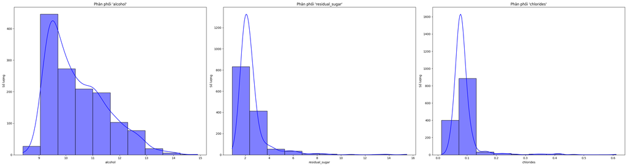

```python
fig, axes = plt.subplots(1, 3, figsize=(30, 8))

# alcohol
sns.histplot(
    data=df, x="alcohol",
    bins=10, kde=True,
    color="blue",
    ax=axes[0]
)
axes[0].set_title("Phân phối 'alcohol'")
axes[0].set_xlabel("alcohol")
axes[0].set_ylabel("Số lượng")

# residual_sugar
sns.histplot(
    data=df, x="residual_sugar",
    bins=10, kde=True,
    color="blue",
    ax=axes[1]
)
axes[1].set_title("Phân phối 'residual_sugar'")
axes[1].set_xlabel("residual_sugar")
axes[1].set_ylabel("Số lượng")

# chlorides
sns.histplot(
    data=df, x="chlorides",
    bins=10, kde=True,
    color="blue",
    ax=axes[2]
)
axes[2].set_title("Phân phối 'chlorides'")
axes[2].set_xlabel("chlorides")
axes[2].set_ylabel("Số lượng")

plt.tight_layout()
plt.show()
```

> cả alcohol, residual_sugar, chlorides có phân không đồng đều

### 4.2 Pairplot

```python
sns.pairplot(
    df,
    diag_kind="hist",
    hue="quality",
    height=5,
    aspect=1.2,  # tăng tỷ lệ chiều ngang
    corner=True,
    palette="Set1"
);
```

[figure not shown]

### 4.3 Histogram

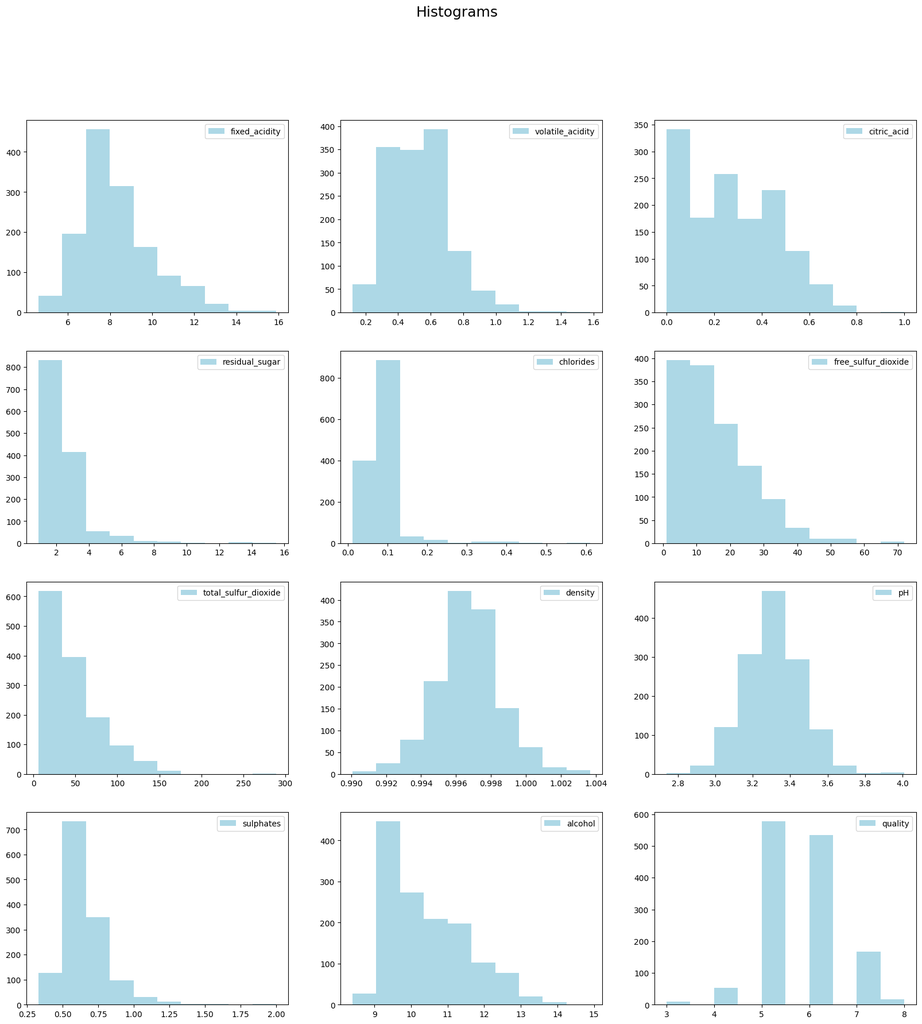

```python
fig, axes = plt.subplots(nrows = 4, ncols = 3, figsize = (20, 20))

for index, column in enumerate(df.columns):
    ax = axes.flatten()[index]
    ax.hist(df[column], color = 'lightblue', label = column)
    ax.legend(loc = "best")
plt.suptitle("Histograms", size = 18)

plt.show()
```

### 4.4 Boxplot

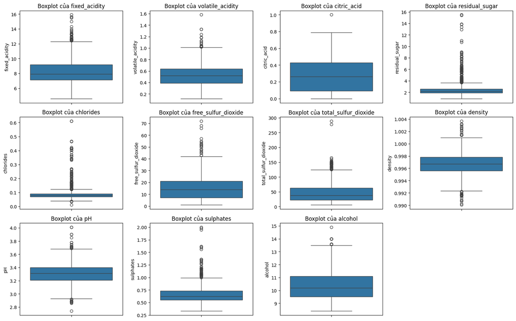

```
Thống kê Median, IQR và số lượng Outliers:
fixed_acidity: Median = 7.90, IQR = 2.10, Outliers = 41
volatile_acidity: Median = 0.52, IQR = 0.25, Outliers = 19
citric_acid: Median = 0.26, IQR = 0.34, Outliers = 1
residual_sugar: Median = 2.20, IQR = 0.70, Outliers = 126
chlorides: Median = 0.08, IQR = 0.02, Outliers = 87
free_sulfur_dioxide: Median = 14.00, IQR = 14.00, Outliers = 26
total_sulfur_dioxide: Median = 38.00, IQR = 41.00, Outliers = 45
density: Median = 1.00, IQR = 0.00, Outliers = 35
pH: Median = 3.31, IQR = 0.19, Outliers = 28
sulphates: Median = 0.62, IQR = 0.18, Outliers = 55
alcohol: Median = 10.20, IQR = 1.60, Outliers = 12
```

```python
columns = [
    "fixed_acidity",
    "volatile_acidity",
    "citric_acid",
    "residual_sugar",
    "chlorides",
    "free_sulfur_dioxide",
    "total_sulfur_dioxide",
    "density",
    "pH",
    "sulphates",
    "alcohol"
]

fig, axes = plt.subplots(3, 4, figsize=(16, 10))
axes = axes.flatten()

for i, col in enumerate(columns):
    sns.boxplot(y=df[col], ax=axes[i])
    axes[i].set_title(f'Boxplot của {col}')

# Ẩn subplot dư thừa nếu có
for j in range(len(columns), len(axes)):
    axes[j].set_visible(False)

plt.tight_layout()
plt.show()

# Tính Median, IQR và số lượng outlier cho từng biến
print("\nThống kê Median, IQR và số lượng Outliers:")
for col in columns:
    median = df[col].median()
    q1 = df[col].quantile(0.25)
    q3 = df[col].quantile(0.75)
    iqr = q3 - q1
    outliers = ((df[col] < q1 - 1.5 * iqr) | (df[col] > q3 + 1.5 * iqr)).sum()
    print(f'{col}: Median = {median:.2f}, IQR = {iqr:.2f}, Outliers = {outliers}')
```

**Chi tiết từng biến**

- **fixed_acidity**: Median = 7.9; IQR = 2.1; Outliers = 41 → phân bố tập trung, có một số giá trị acid cố định cao/thấp bất thường.
- **volatile_acidity**: Median = 0.52; IQR = 0.25; Outliers = 19 → khá gọn, ít ngoại lai.
- **citric_acid**: Median = 0.26; IQR = 0.34; Outliers = 1 → ổn định, gần như không có ngoại lai.
- **residual_sugar**: Median = 2.2; IQR = 0.7; Outliers = 126 → đuôi dài, nhiều mẫu đường dư khác thường.
- **chlorides**: Median = 0.08; IQR = 0.02; Outliers = 87 → nhiều mẫu muối cao bất thường.
- **free_sulfur_dioxide**: Median = 14.0; IQR = 14.0; Outliers = 26 → phân tán mạnh, có điểm SO₂ tự do cao bất thường.
- **total_sulfur_dioxide**: Median = 38.0; IQR = 41.0; Outliers = 45 → SO₂ tổng phân tán mạnh.
- **density**: Median = 1.00; IQR ≈ 0.00; Outliers = 35 → mật độ hầu như sát 1, nhưng có vài điểm khác biệt.
- **pH**: Median = 3.31; IQR = 0.19; Outliers = 28 → pH ổn định, ít ngoại lai.
- **sulphates**: Median = 0.62; IQR = 0.18; Outliers = 55 → vẫn có nhiều mẫu sulphates cao.
- **alcohol**: Median = 10.2; IQR = 1.6; Outliers = 12 → tập trung, ít ngoại lai.

**Kết luận **

- Phần lớn biến hóa học của rượu vang **khá tập trung (IQR nhỏ)**.
- Một số biến có **nhiều ngoại lai** như `residual_sugar`, `chlorides`, `total_sulfur_dioxide`.
- Khi phân tích hoặc xây dựng mô hình nên cân nhắc **xử lý ngoại lai**

#### 4.5 Correlation (Heatmap)

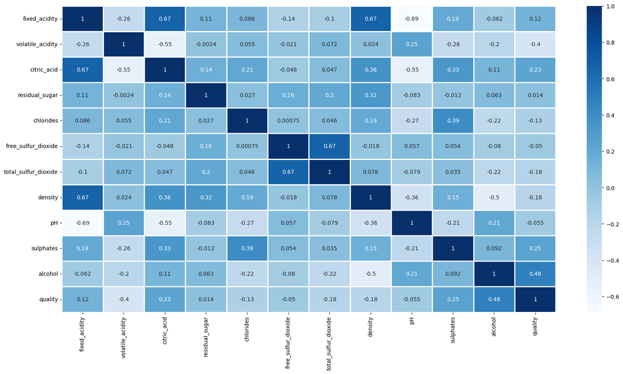

```python
plt.figure(figsize = [20, 10], facecolor = 'white')
sns.heatmap(df.corr(), annot = True, linewidths = 2, cmap = "Blues");
```

'Free sulfur dioxide' và 'Total sulfur dioxide' có tương quan dương khá cao (r ≈ 0.67).

'pH' và 'Fixed acidity' có tương quan âm khá cao (r ≈ -0.68).

Một số cặp biến khác có mức tương quan khoảng 0.5 (trung bình–khá).